# Final Assignment

Matthias Aulbach

08.03.2017

Here is a link to my data wrangling script:

https://github.com/matthiasaulbach/IODS-final/blob/master/create_goal.R

# Abstract

In a dataset of goals set by depression patients in sessions with different therapists, I analyzed relations between therapists, goal types, goal process and depression symptoms. While neither goal types therapist seem to be predictive of goal progress, therapists do seem to have a differential impact on depression symptom scores.

# Description of the dataset

Thi dataset comes from an intervention study with depression patients. Each patient had several sessions with a therapist in each of which they set three goals. These goals are the focus of my analysis: every case represents a goal (not a patient). The goal content was coded into binary variables (since some goals belong to more than one category). In addition, we have here the standardized goal progress and an entry and end score for depression symptoms. I also created a variable that indicates changes in depression scores and a binary variable that tells us whether or not a patient was above the cutoff value of the depression questionnaire at the end of the treatment (see the data wrangling script). Therapists are coded into a categorical variable.

# Research questions:

1. Does the kind of goal that has been set have an influence on a) goal progress and b) symptom change? My hypothesis is that goal content does make a difference, i.e. some kinds of goals lead to more progress and larger symptom change.
2. Do the therapists differ in their effectiveness regarding a) goal progress and b) symptom change? Also for therapists, I expect differences since surely, not all therapists are equally qualified.
3. Does it depend on the therapist which kind of goal is chosen? Again, my hypothesis is that therapists have “favourites” regarding goal content, i.e. that there are differences in goal content depending on the therapist.

# Getting the data file and summary

```r
Goals <- read.table("Z:\\Desktop\\Data Analysis Keegan\\Goals")
colnames(Goals)
```

```
##  [1] "pagol"             "dietgol"           "alcogol"
##  [4] "addictgol"         "sleepgol"          "relaxgol"
##  [7] "socgol"            "emogol"            "coggoal"
## [10] "workgoal"          "homegoal"          "hobgoal"
## [13] "hygmdgol"          "treatgol"          "badgoal"
## [16] "assgoal"           "reenggol"          "unclearg"
## [19] "therapist"         "zgoalprogress"     "phqentry"
## [22] "phqend"            "goalprogress_full" "phq_change"
## [25] "depr"
```

```r
str(Goals)
```

```
## 'data.frame':    828 obs. of  25 variables:
##  $ pagol            : logi  FALSE FALSE FALSE FALSE FALSE FALSE ...
##  $ dietgol          : logi  FALSE FALSE FALSE FALSE FALSE FALSE ...
##  $ alcogol          : logi  FALSE FALSE FALSE FALSE FALSE FALSE ...
##  $ addictgol        : logi  FALSE FALSE FALSE FALSE FALSE FALSE ...
##  $ sleepgol         : logi  FALSE FALSE FALSE FALSE FALSE FALSE ...
##  $ relaxgol         : logi  FALSE FALSE FALSE FALSE FALSE FALSE ...
##  $ socgol           : logi  FALSE FALSE TRUE FALSE FALSE TRUE ...
##  $ emogol           : logi  FALSE FALSE FALSE FALSE FALSE FALSE ...
##  $ coggoal          : logi  FALSE FALSE FALSE FALSE FALSE FALSE ...
##  $ workgoal         : logi  FALSE FALSE FALSE FALSE FALSE FALSE ...
##  $ homegoal         : logi  FALSE FALSE FALSE FALSE FALSE FALSE ...
##  $ hobgoal          : logi  FALSE FALSE FALSE FALSE FALSE FALSE ...
##  $ hygmdgol         : logi  FALSE FALSE FALSE FALSE FALSE FALSE ...
##  $ treatgol         : logi  TRUE FALSE FALSE TRUE FALSE FALSE ...
##  $ badgoal          : logi  FALSE FALSE FALSE FALSE FALSE FALSE ...
##  $ assgoal          : logi  FALSE FALSE FALSE FALSE FALSE FALSE ...
##  $ reenggol         : logi  FALSE FALSE FALSE FALSE FALSE FALSE ...
##  $ unclearg         : logi  FALSE FALSE FALSE FALSE FALSE FALSE ...
##  $ therapist        : Factor w/ 18 levels "AC","BD","CM",..: 5 5 5 5 5 5 5 5 5 12 ...
##  $ zgoalprogress    : num  0.6188 0.0204 0.9608 0.1628 0.4763 ...
##  $ phqentry         : int  24 24 24 24 24 24 24 24 24 19 ...
##  $ phqend           : int  3 3 3 3 3 3 3 3 3 19 ...
##  $ goalprogress_full: int  82 61 94 66 77 98 87 85 98 39 ...
##  $ phq_change       : int  21 21 21 21 21 21 21 21 21 0 ...
##  $ depr             : logi  FALSE FALSE FALSE FALSE FALSE FALSE ...
```

```r
summary(Goals)
```

```
##    pagol          dietgol         alcogol        addictgol
##  Mode :logical   Mode :logical   Mode :logical   Mode :logical
##  FALSE:707       FALSE:800       FALSE:825       FALSE:818
##  TRUE :121       TRUE :28        TRUE :3         TRUE :10
##  NA's :0         NA's :0         NA's :0         NA's :0
##
##
##
##   sleepgol        relaxgol         socgol          emogol
##  Mode :logical   Mode :logical   Mode :logical   Mode :logical
##  FALSE:798       FALSE:798       FALSE:700       FALSE:791
##  TRUE :30        TRUE :30        TRUE :128       TRUE :37
##  NA's :0         NA's :0         NA's :0         NA's :0
##
##
##
##   coggoal         workgoal        homegoal        hobgoal
##  Mode :logical   Mode :logical   Mode :logical   Mode :logical
##  FALSE:796       FALSE:754       FALSE:711       FALSE:754
##  TRUE :32        TRUE :74        TRUE :117       TRUE :74
##  NA's :0         NA's :0         NA's :0         NA's :0
##
##
##
##   hygmdgol        treatgol        badgoal         assgoal
##  Mode :logical   Mode :logical   Mode :logical   Mode :logical
##  FALSE:810       FALSE:669       FALSE:793       FALSE:801
##  TRUE :18        TRUE :159       TRUE :35        TRUE :27
##  NA's :0         NA's :0         NA's :0         NA's :0
##
##
##
##   reenggol        unclearg         therapist   zgoalprogress
##  Mode :logical   Mode :logical   JS     :162   Min.   :-1.7180
##  FALSE:807       FALSE:735       LG     :162   1st Qu.:-0.8702
##  TRUE :21        TRUE :93        HD     :144   Median : 0.2483
##  NA's :0         NA's :0         JL     : 63   Mean   : 0.0178
##                                  LB     : 54   3rd Qu.: 0.9893
##                                  GF     : 27   Max.   : 1.1318
##                                  (Other):216   NA's   :160
##     phqentry         phqend       goalprogress_full   phq_change
##  Min.   : 9.00   Min.   : 0.000   Min.   :  0.00    Min.   :-4.000
##  1st Qu.:13.00   1st Qu.: 4.000   1st Qu.:  3.00    1st Qu.: 4.000
##  Median :17.00   Median : 8.000   Median : 51.00    Median : 8.500
##  Mean   :16.99   Mean   : 8.543   Mean   : 49.14    Mean   : 8.446
##  3rd Qu.:21.00   3rd Qu.:11.000   3rd Qu.: 90.00    3rd Qu.:12.250
##  Max.   :26.00   Max.   :23.000   Max.   :100.00    Max.   :21.000
##
##     depr
##  Mode :logical
##  FALSE:567
##  TRUE :261
##  NA's :0
##
##
##
```

The goals set most often are physical activity related, from the social domain (such as meeting with friends), related to the home or somehow connected to the treatment. Goals related to alcohol consumption or other addictive behaviors are very rare. PHQ (i.e. depression) scores range from 9 (surprising, since 10 is the cutof value) to 26, which is extremely high. On average, patients had a score of 17, indicating a “moderately severe depression”. At the end of treatment, average PHQ scores were at 8.5. which is under the cutoff for a clinically significant depression. On average, PHQ scores decreased by 8.4 points. However, 261 patients (more than a quarter) were still considered as having a depression at the end of treatment.

## Relations between variables

Let’s take a look at relations between some of our variables.

```r
reg1 <- lm(phqentry ~ phqend, data = Goals)
summary(reg1)
```

```
##
## Call:
## lm(formula = phqentry ~ phqend, data = Goals)
##
## Residuals:
##     Min      1Q  Median      3Q     Max
## -8.1019 -3.3609 -0.0778  3.3951  8.3800
##
## Coefficients:
##             Estimate Std. Error t value Pr(>|t|)
## (Intercept) 14.87899    0.27054  54.997   <2e-16 ***
## phqend       0.24699    0.02673   9.241   <2e-16 ***
## ---
## Signif. codes:  0 '***' 0.001 '**' 0.01 '*' 0.05 '.' 0.1 ' ' 1
##
## Residual standard error: 4.175 on 826 degrees of freedom
## Multiple R-squared:  0.09369,    Adjusted R-squared:  0.0926
## F-statistic: 85.39 on 1 and 826 DF,  p-value: < 2.2e-16
```

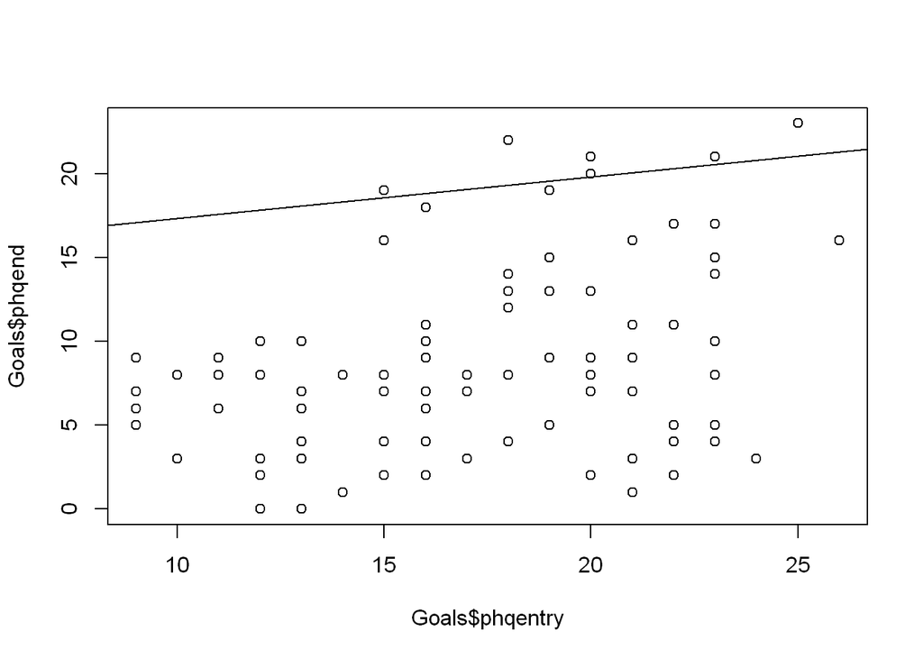

```r
plot(Goals$phqentry, Goals$phqend)
abline(reg1)
```

“phqentry”" and “phqend”" are correlated. This was to be expected when assuming that most patients’ score goes down a certain amount of points. Someone who has a very severe depression in the beginning still has more symptoms in the end while a mild depression in the beginning might be cured after therapy.

```r
reg2 <- lm(phqentry ~ zgoalprogress, data=Goals)
summary(reg2)
```

```
##
## Call:
## lm(formula = phqentry ~ zgoalprogress, data = Goals)
##
## Residuals:
##     Min      1Q  Median      3Q     Max
## -7.9806 -3.9476 -0.2659  4.0343  9.4446
##
## Coefficients:
##               Estimate Std. Error t value Pr(>|t|)
## (Intercept)    16.8117     0.1707  98.482   <2e-16 ***
## zgoalprogress   0.1492     0.1722   0.867    0.386
## ---
## Signif. codes:  0 '***' 0.001 '**' 0.01 '*' 0.05 '.' 0.1 ' ' 1
##
## Residual standard error: 4.411 on 666 degrees of freedom
##   (160 observations deleted due to missingness)
## Multiple R-squared:  0.001126,   Adjusted R-squared:  -0.0003734
## F-statistic: 0.751 on 1 and 666 DF,  p-value: 0.3865
```

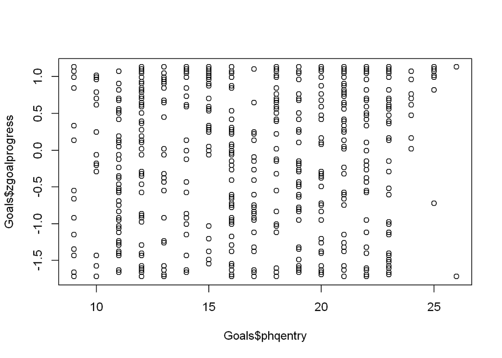

```r
plot(Goals$phqentry, Goals$zgoalprogress)
abline(reg2)
```

“phqentry”" and goal progress are not correlated. No matter how depressed a person was at the outset, the goal progress is more or less the same.

```r
reg4 <- lm(zgoalprogress ~ phqend, data = Goals)
summary(reg4)
```

```
##
## Call:
## lm(formula = zgoalprogress ~ phqend, data = Goals)
##
## Residuals:
##     Min      1Q  Median      3Q     Max
## -1.7641 -0.9138  0.2329  0.9525  1.1838
##
## Coefficients:
##              Estimate Std. Error t value Pr(>|t|)
## (Intercept)  0.055427   0.070990   0.781    0.435
## phqend      -0.004672   0.007414  -0.630    0.529
##
## Residual standard error: 0.9924 on 666 degrees of freedom
##   (160 observations deleted due to missingness)
## Multiple R-squared:  0.0005959,  Adjusted R-squared:  -0.0009047
## F-statistic: 0.3971 on 1 and 666 DF,  p-value: 0.5288
```

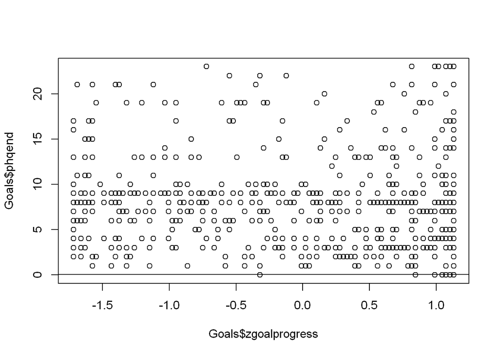

```r
plot(Goals$zgoalprogress, Goals$phqend)
abline(reg4)
```

“phqend”" and goal progress are not correlated. Obviously, making progress on one’s goals doesn’t help cure depressive symptoms.

```r
reg5 <- lm(zgoalprogress ~ phq_change, data = Goals)
summary(reg5)
```

```
##
## Call:
## lm(formula = zgoalprogress ~ phq_change, data = Goals)
##
## Residuals:
##     Min      1Q  Median      3Q     Max
## -1.7788 -0.8823  0.2266  0.9616  1.2024
##
## Coefficients:
##              Estimate Std. Error t value Pr(>|t|)
## (Intercept) -0.054190   0.069897  -0.775    0.438
## phq_change   0.008218   0.006669   1.232    0.218
##
## Residual standard error: 0.9916 on 666 degrees of freedom
##   (160 observations deleted due to missingness)
## Multiple R-squared:  0.002274,   Adjusted R-squared:  0.0007764
## F-statistic: 1.518 on 1 and 666 DF,  p-value: 0.2183
```

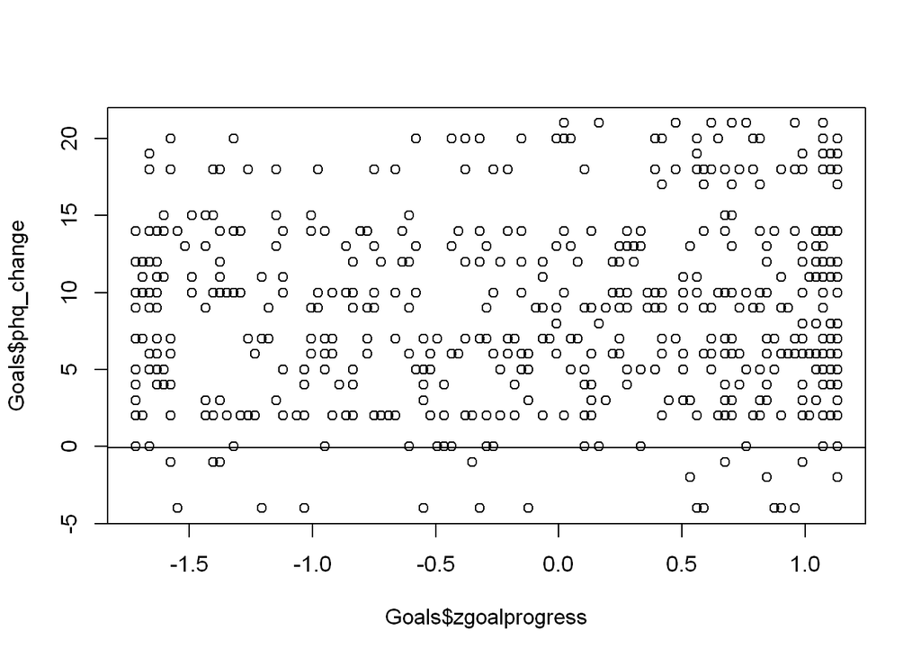

```r
plot(Goals$zgoalprogress, Goals$phq_change)
abline(reg5)
```

Logically, “phq_change”" is not correlated with goal progress either (since phq_change is made up of phqentry and phqend).

What’s also interesting for a start is how often the goals types were set. Let’s see a summary:

```r
summary(Goals[1:18])
```

```
##    pagol          dietgol         alcogol        addictgol
##  Mode :logical   Mode :logical   Mode :logical   Mode :logical
##  FALSE:707       FALSE:800       FALSE:825       FALSE:818
##  TRUE :121       TRUE :28        TRUE :3         TRUE :10
##  NA's :0         NA's :0         NA's :0         NA's :0
##   sleepgol        relaxgol         socgol          emogol
##  Mode :logical   Mode :logical   Mode :logical   Mode :logical
##  FALSE:798       FALSE:798       FALSE:700       FALSE:791
##  TRUE :30        TRUE :30        TRUE :128       TRUE :37
##  NA's :0         NA's :0         NA's :0         NA's :0
##   coggoal         workgoal        homegoal        hobgoal
##  Mode :logical   Mode :logical   Mode :logical   Mode :logical
##  FALSE:796       FALSE:754       FALSE:711       FALSE:754
##  TRUE :32        TRUE :74        TRUE :117       TRUE :74
##  NA's :0         NA's :0         NA's :0         NA's :0
##   hygmdgol        treatgol        badgoal         assgoal
##  Mode :logical   Mode :logical   Mode :logical   Mode :logical
##  FALSE:810       FALSE:669       FALSE:793       FALSE:801
##  TRUE :18        TRUE :159       TRUE :35        TRUE :27
##  NA's :0         NA's :0         NA's :0         NA's :0
##   reenggol        unclearg
##  Mode :logical   Mode :logical
##  FALSE:807       FALSE:735
##  TRUE :21        TRUE :93
##  NA's :0         NA's :0
```

# Data Analysis

## 1. a) Relation between goal content and goal progress

First, I want to investigate whether goals differ in regard to the progress that patients make in them. To study this, I will plot the different goals against “zgoalprogress”" (Note that “zgoalprogress” is a standardized value).

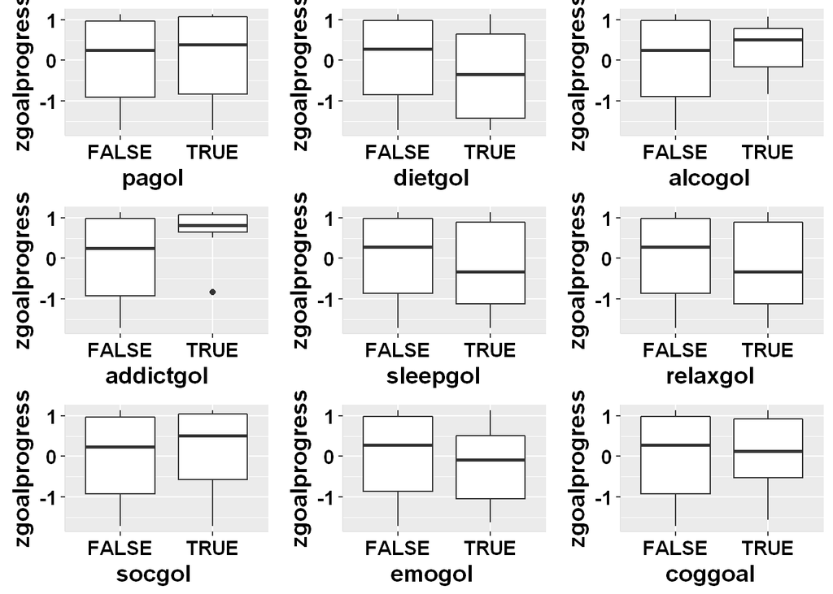

```r
library(ggplot2)
library(easyGgplot2)
b1 <- ggplot2.boxplot(data=Goals, yName = "zgoalprogress", xName = "pagol")
b2 <- ggplot2.boxplot(data=Goals, yName = "zgoalprogress", xName ="dietgol")
b3 <- ggplot2.boxplot(data=Goals, yName = "zgoalprogress", xName ="alcogol")
b4 <- ggplot2.boxplot(data=Goals, yName = "zgoalprogress", xName ="addictgol")
b5 <- ggplot2.boxplot(data=Goals, yName = "zgoalprogress", xName ="sleepgol")
b6 <- ggplot2.boxplot(data=Goals, yName = "zgoalprogress", xName ="relaxgol")
b7 <- ggplot2.boxplot(data=Goals, yName = "zgoalprogress", xName ="socgol")
b8 <- ggplot2.boxplot(data=Goals, yName = "zgoalprogress", xName ="emogol")
b9 <- ggplot2.boxplot(data=Goals, yName = "zgoalprogress", xName ="coggoal")
b10 <- ggplot2.boxplot(data=Goals, yName = "zgoalprogress", xName ="workgoal")
b11 <- ggplot2.boxplot(data=Goals, yName = "zgoalprogress", xName ="homegoal")
b12 <- ggplot2.boxplot(data=Goals, yName = "zgoalprogress", xName ="hobgoal")
b13 <- ggplot2.boxplot(data=Goals, yName = "zgoalprogress", xName ="hygmdgol")
b14 <- ggplot2.boxplot(data=Goals, yName = "zgoalprogress", xName ="treatgol")
b15 <- ggplot2.boxplot(data=Goals, yName = "zgoalprogress", xName ="badgoal")
b16 <- ggplot2.boxplot(data=Goals, yName = "zgoalprogress", xName ="assgoal")
b17 <- ggplot2.boxplot(data=Goals, yName = "zgoalprogress", xName ="reenggol")
b18 <- ggplot2.boxplot(data=Goals, yName = "zgoalprogress", xName ="unclearg")

ggplot2.multiplot (b1, b2, b3,b4, b5, b6, b7, b8, b9, cols = 3)
```

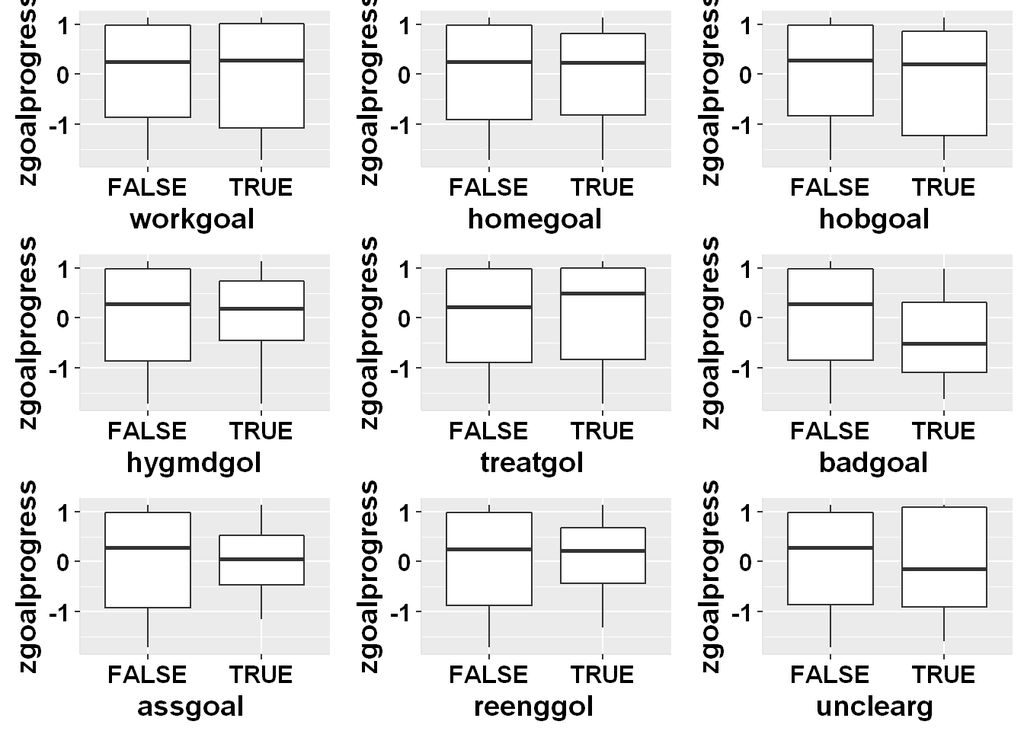

```r
ggplot2.multiplot (b10, b11, b12, b13, b14, b15, b16, b17, b18, cols = 3)
```

```r
model_goals <- lm(zgoalprogress ~ pagol+dietgol+alcogol+addictgol+sleepgol+relaxgol+socgol+emogol+coggoal+workgoal+homegoal+hobgoal+hygmdgol+treatgol+badgoal+assgoal+reenggol+unclearg, data = Goals)
summary(model_goals)
```

```
##
## Call:
## lm(formula = zgoalprogress ~ pagol + dietgol + alcogol + addictgol +
##     sleepgol + relaxgol + socgol + emogol + coggoal + workgoal +
##     homegoal + hobgoal + hygmdgol + treatgol + badgoal + assgoal +
##     reenggol + unclearg, data = Goals)
##
## Residuals:
##     Min      1Q  Median      3Q     Max
## -1.8699 -0.8351  0.2481  0.8990  1.7775
##
## Coefficients: (1 not defined because of singularities)
##               Estimate Std. Error t value Pr(>|t|)
## (Intercept)    0.06727    0.11559   0.582  0.56077
## pagolTRUE      0.06047    0.13127   0.461  0.64521
## dietgolTRUE   -0.63811    0.21836  -2.922  0.00360 **
## alcogolTRUE   -0.98074    0.70535  -1.390  0.16487
## addictgolTRUE  1.16180    0.41917   2.772  0.00574 **
## sleepgolTRUE  -0.39695    0.20119  -1.973  0.04892 *
## relaxgolTRUE        NA         NA      NA       NA
## socgolTRUE     0.08119    0.13300   0.610  0.54177
## emogolTRUE     0.07206    0.24659   0.292  0.77020
## coggoalTRUE    0.06716    0.20466   0.328  0.74290
## workgoalTRUE  -0.06597    0.16211  -0.407  0.68418
## homegoalTRUE  -0.07489    0.13505  -0.555  0.57941
## hobgoalTRUE   -0.20891    0.14680  -1.423  0.15518
## hygmdgolTRUE  -0.07589    0.26225  -0.289  0.77238
## treatgolTRUE   0.08154    0.13608   0.599  0.54923
## badgoalTRUE   -0.54138    0.25066  -2.160  0.03115 *
## assgoalTRUE   -0.09697    0.23304  -0.416  0.67748
## reenggolTRUE   0.13080    0.23351   0.560  0.57556
## uncleargTRUE  -0.02092    0.21433  -0.098  0.92229
## ---
## Signif. codes:  0 '***' 0.001 '**' 0.01 '*' 0.05 '.' 0.1 ' ' 1
##
## Residual standard error: 0.9833 on 650 degrees of freedom
##   (160 observations deleted due to missingness)
## Multiple R-squared:  0.04239,    Adjusted R-squared:  0.01734
## F-statistic: 1.692 on 17 and 650 DF,  p-value: 0.03967
```

## 1.b) Goal content and PHQ scores at end of treatment

Now obviously, our main concern is not goal progress but rather that patients reduce their depression symptoms. Therefore, let’s see which kind of goal is associated with the lowest scores at the end of the treatment. To get an idea of that, I will plot goals against depression scores at the end of treatment (phqend). Lower scores mean fewer/less intense symptoms, i.e. are more desirable.

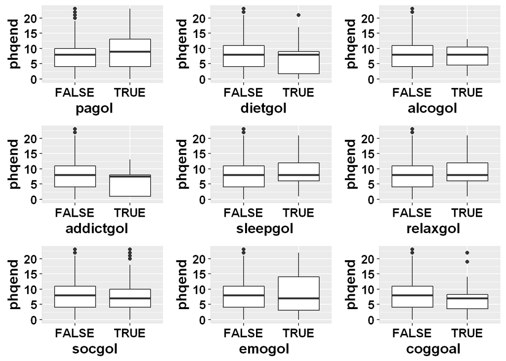

```r
b20 <- ggplot2.boxplot(data=Goals, yName = "phqend", xName = "pagol")
b21 <- ggplot2.boxplot(data=Goals, yName = "phqend", xName = "dietgol")
b22 <- ggplot2.boxplot(data=Goals, yName = "phqend", xName = "alcogol")
b23 <- ggplot2.boxplot(data=Goals, yName = "phqend", xName = "addictgol")
b24 <- ggplot2.boxplot(data=Goals, yName = "phqend", xName = "sleepgol")
b25 <- ggplot2.boxplot(data=Goals, yName = "phqend", xName = "relaxgol")
b26 <- ggplot2.boxplot(data=Goals, yName = "phqend", xName = "socgol")
b27 <- ggplot2.boxplot(data=Goals, yName = "phqend", xName = "emogol")
b28 <- ggplot2.boxplot(data=Goals, yName = "phqend", xName = "coggoal")
b29 <- ggplot2.boxplot(data=Goals, yName = "phqend", xName = "workgoal")
b30 <- ggplot2.boxplot(data=Goals, yName = "phqend", xName = "homegoal")
b31 <- ggplot2.boxplot(data=Goals, yName = "phqend", xName = "hobgoal")
b32 <-ggplot2.boxplot(data=Goals, yName = "phqend", xName = "hygmdgol")
b33 <- ggplot2.boxplot(data=Goals, yName = "phqend", xName = "treatgol")
b34 <-ggplot2.boxplot(data=Goals, yName = "phqend", xName = "badgoal")
b35 <-ggplot2.boxplot(data=Goals, yName = "phqend", xName = "assgoal")
b36 <-ggplot2.boxplot(data=Goals, yName = "phqend", xName = "reenggol")
b37 <-ggplot2.boxplot(data=Goals, yName = "phqend", xName = "unclearg")

ggplot2.multiplot (b20, b21, b22, b23, b24, b25, b26, b27,b28, cols = 3)
```

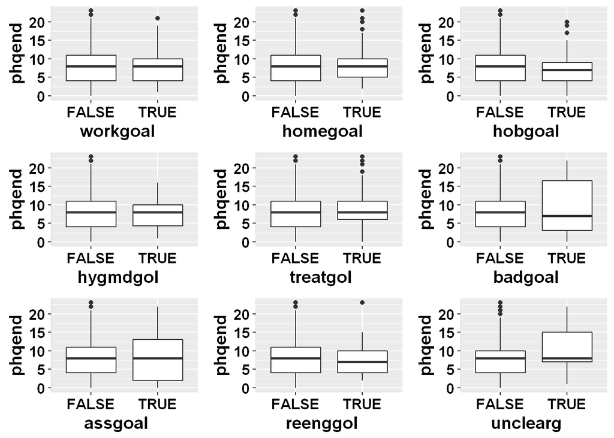

```r
ggplot2.multiplot (b29, b30, b31, b32, b33, b34, b35, b36, b37, cols = 3)
```

It seems like the kind of goal doesn’t affect the strength of depression symptoms at the end of the treatment. Let’s run a regression model predicting PHQ at the end of treatment with kinds of goals to see if there is any meaningful predictive power.

```r
model_goals_phq <- lm (phqend ~ pagol+dietgol+alcogol+addictgol+sleepgol+relaxgol+socgol+emogol+coggoal+workgoal+homegoal+hobgoal+hygmdgol+treatgol+badgoal+assgoal+reenggol+unclearg, data = Goals)
summary(model_goals_phq)
```

```
##
## Call:
## lm(formula = phqend ~ pagol + dietgol + alcogol + addictgol +
##     sleepgol + relaxgol + socgol + emogol + coggoal + workgoal +
##     homegoal + hobgoal + hygmdgol + treatgol + badgoal + assgoal +
##     reenggol + unclearg, data = Goals)
##
## Residuals:
##     Min      1Q  Median      3Q     Max
## -9.4661 -4.1454 -0.8477  2.2408 15.3133
##
## Coefficients: (1 not defined because of singularities)
##               Estimate Std. Error t value Pr(>|t|)
## (Intercept)    8.58241    0.57248  14.992   <2e-16 ***
## pagolTRUE      0.84736    0.64909   1.305   0.1921
## dietgolTRUE   -0.70922    1.13658  -0.624   0.5328
## alcogolTRUE    1.52475    3.79072   0.402   0.6876
## addictgolTRUE -2.77383    2.15555  -1.287   0.1985
## sleepgolTRUE  -0.10461    1.05858  -0.099   0.9213
## relaxgolTRUE        NA         NA      NA       NA
## socgolTRUE    -0.39306    0.66264  -0.593   0.5532
## emogolTRUE    -0.08427    1.24876  -0.067   0.9462
## coggoalTRUE   -1.67848    1.03324  -1.624   0.1047
## workgoalTRUE  -0.82320    0.80312  -1.025   0.3057
## homegoalTRUE  -0.35384    0.67988  -0.520   0.6029
## hobgoalTRUE   -1.43702    0.75852  -1.894   0.0585 .
## hygmdgolTRUE  -0.16346    1.35741  -0.120   0.9042
## treatgolTRUE   0.57456    0.68538   0.838   0.4021
## badgoalTRUE    0.88364    1.24461   0.710   0.4779
## assgoalTRUE   -0.47322    1.20133  -0.394   0.6937
## reenggolTRUE  -0.89568    1.24651  -0.719   0.4726
## uncleargTRUE   1.49929    0.73042   2.053   0.0404 *
## ---
## Signif. codes:  0 '***' 0.001 '**' 0.01 '*' 0.05 '.' 0.1 ' ' 1
##
## Residual standard error: 5.404 on 810 degrees of freedom
## Multiple R-squared:  0.03063,    Adjusted R-squared:  0.01028
## F-statistic: 1.505 on 17 and 810 DF,  p-value: 0.08555
```

As for goal progress, PHQ scores at the end of the treatment are very poorly predicted by goal content: the adjusted R square is 0.010.

Since the end score of PHQ is correlated to the entry score (as we have seen earlier), let’s rather look at change scores: How does goal content influence changes in depressive symptoms? Again, I run a regression model.

```r
model_goals_phqchange <- lm (phq_change ~ pagol+dietgol+alcogol+addictgol+sleepgol+relaxgol+socgol+emogol+coggoal+workgoal+homegoal+hobgoal+hygmdgol+treatgol+badgoal+assgoal+reenggol+unclearg, data = Goals)
summary(model_goals_phqchange)
```

```
##
## Call:
## lm(formula = phq_change ~ pagol + dietgol + alcogol + addictgol +
##     sleepgol + relaxgol + socgol + emogol + coggoal + workgoal +
##     homegoal + hobgoal + hygmdgol + treatgol + badgoal + assgoal +
##     reenggol + unclearg, data = Goals)
##
## Residuals:
##      Min       1Q   Median       3Q      Max
## -13.5909  -4.0959  -0.2688   3.7358  15.9661
##
## Coefficients: (1 not defined because of singularities)
##               Estimate Std. Error t value Pr(>|t|)
## (Intercept)     8.1586     0.6164  13.236  < 2e-16 ***
## pagolTRUE      -0.4121     0.6989  -0.590  0.55560
## dietgolTRUE    -0.1460     1.2237  -0.119  0.90507
## alcogolTRUE     0.5487     4.0815   0.134  0.89310
## addictgolTRUE   3.9594     2.3209   1.706  0.08839 .
## sleepgolTRUE   -0.1711     1.1398  -0.150  0.88072
## relaxgolTRUE        NA         NA      NA       NA
## socgolTRUE      1.1102     0.7135   1.556  0.12009
## emogolTRUE      3.1183     1.3445   2.319  0.02063 *
## coggoalTRUE     1.4323     1.1125   1.287  0.19829
## workgoalTRUE    0.7579     0.8647   0.876  0.38103
## homegoalTRUE   -0.0544     0.7320  -0.074  0.94078
## hobgoalTRUE     0.6738     0.8167   0.825  0.40958
## hygmdgolTRUE   -1.0627     1.4615  -0.727  0.46736
## treatgolTRUE    0.2147     0.7379   0.291  0.77116
## badgoalTRUE    -3.5931     1.3401  -2.681  0.00748 **
## assgoalTRUE    -1.3766     1.2935  -1.064  0.28754
## reenggolTRUE    2.3801     1.3421   1.773  0.07653 .
## uncleargTRUE   -0.5316     0.7864  -0.676  0.49927
## ---
## Signif. codes:  0 '***' 0.001 '**' 0.01 '*' 0.05 '.' 0.1 ' ' 1
##
## Residual standard error: 5.818 on 810 degrees of freedom
## Multiple R-squared:  0.02881,    Adjusted R-squared:  0.008425
## F-statistic: 1.413 on 17 and 810 DF,  p-value: 0.1223
```

Again, the whole model does very poorly: adjusted R square is just 0.008.

“emogol” and “badgoal” have significant influence in the model. Let’s take another look at their boxplots.

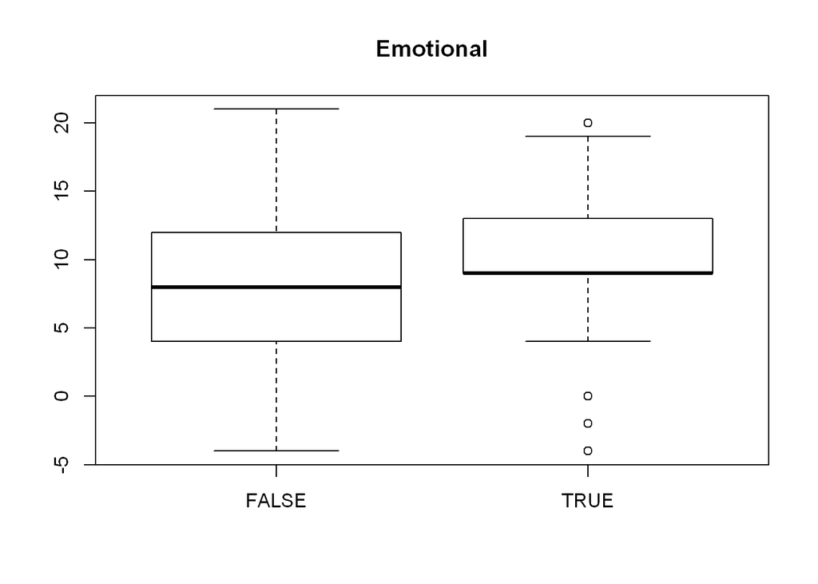

```r
boxplot(phq_change ~ emogol, data = Goals, main = "Emotional")
```

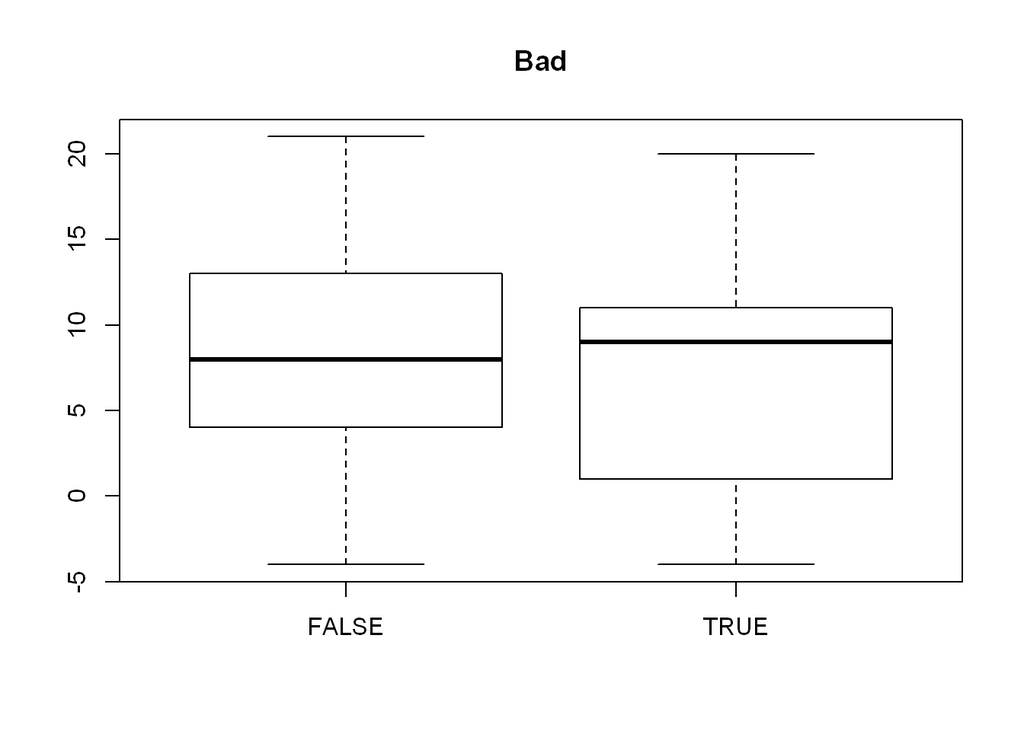

```r
boxplot(phq_change ~ badgoal, data = Goals, main = "Bad")
```

We might argue that the precise score at the end of the treatment or the change in symptoms are not most interesting but rather whether a patient is still depressed or not. Therefore, let’s look at some crosstable between goal content and the binary variable “depr” that indicates whether or not a patient was still above the cutoff value in the depression questionnaire.

```r
library(gmodels)
CrossTable (Goals$depr, Goals$pagol)
```

```
##
##
##    Cell Contents
## |-------------------------|
## |                       N |
## | Chi-square contribution |
## |           N / Row Total |
## |           N / Col Total |
## |         N / Table Total |
## |-------------------------|
##
##
## Total Observations in Table:  828
##
##
##              | Goals$pagol
##   Goals$depr |     FALSE |      TRUE | Row Total |
## -------------|-----------|-----------|-----------|
##        FALSE |       499 |        68 |       567 |
##              |     0.456 |     2.665 |           |
##              |     0.880 |     0.120 |     0.685 |
##              |     0.706 |     0.562 |           |
##              |     0.603 |     0.082 |           |
## -------------|-----------|-----------|-----------|
##         TRUE |       208 |        53 |       261 |
##              |     0.991 |     5.788 |           |
##              |     0.797 |     0.203 |     0.315 |
##              |     0.294 |     0.438 |           |
##              |     0.251 |     0.064 |           |
## -------------|-----------|-----------|-----------|
## Column Total |       707 |       121 |       828 |
##              |     0.854 |     0.146 |           |
## -------------|-----------|-----------|-----------|
##
##
```

```r
CrossTable (Goals$depr, Goals$socgol)
```

```
##
##
##    Cell Contents
## |-------------------------|
## |                       N |
## | Chi-square contribution |
## |           N / Row Total |
## |           N / Col Total |
## |         N / Table Total |
## |-------------------------|
##
##
## Total Observations in Table:  828
##
##
##              | Goals$socgol
##   Goals$depr |     FALSE |      TRUE | Row Total |
## -------------|-----------|-----------|-----------|
##        FALSE |       480 |        87 |       567 |
##              |     0.001 |     0.005 |           |
##              |     0.847 |     0.153 |     0.685 |
##              |     0.686 |     0.680 |           |
##              |     0.580 |     0.105 |           |
## -------------|-----------|-----------|-----------|
##         TRUE |       220 |        41 |       261 |
##              |     0.002 |     0.011 |           |
##              |     0.843 |     0.157 |     0.315 |
##              |     0.314 |     0.320 |           |
##              |     0.266 |     0.050 |           |
## -------------|-----------|-----------|-----------|
## Column Total |       700 |       128 |       828 |
##              |     0.845 |     0.155 |           |
## -------------|-----------|-----------|-----------|
##
##
```

Let’s take a closer look at the crosstable for PA goals. In total, 14.6% of goals are PA goals and 31.5% of patients are still depressed after the treatment. Of those who do have PA goals 43.8% are still depressed. This does not shed good light on physical activity goals. The other category that has been used quite frequently were social goals, so let’s take a closer look at that as well. 32% of those with a social goal were still depressed after treatment which is pretty much the average of 31.5%.

I’m including ouput (and optinally code) for the other goal categories, for reasons of completeness. I chose to look at PA and social goals more closely because they were set quite often.

```r
CrossTable (Goals$depr, Goals$dietgol)
```

```
##
##
##    Cell Contents
## |-------------------------|
## |                       N |
## | Chi-square contribution |
## |           N / Row Total |
## |           N / Col Total |
## |         N / Table Total |
## |-------------------------|
##
##
## Total Observations in Table:  828
##
##
##              | Goals$dietgol
##   Goals$depr |     FALSE |      TRUE | Row Total |
## -------------|-----------|-----------|-----------|
##        FALSE |       545 |        22 |       567 |
##              |     0.015 |     0.417 |           |
##              |     0.961 |     0.039 |     0.685 |
##              |     0.681 |     0.786 |           |
##              |     0.658 |     0.027 |           |
## -------------|-----------|-----------|-----------|
##         TRUE |       255 |         6 |       261 |
##              |     0.032 |     0.905 |           |
##              |     0.977 |     0.023 |     0.315 |
##              |     0.319 |     0.214 |           |
##              |     0.308 |     0.007 |           |
## -------------|-----------|-----------|-----------|
## Column Total |       800 |        28 |       828 |
##              |     0.966 |     0.034 |           |
## -------------|-----------|-----------|-----------|
##
##
```

```r
CrossTable (Goals$depr, Goals$alcogol)
```

```
##
##
##    Cell Contents
## |-------------------------|
## |                       N |
## | Chi-square contribution |
## |           N / Row Total |
## |           N / Col Total |
## |         N / Table Total |
## |-------------------------|
##
##
## Total Observations in Table:  828
##
##
##              | Goals$alcogol
##   Goals$depr |     FALSE |      TRUE | Row Total |
## -------------|-----------|-----------|-----------|
##        FALSE |       565 |         2 |       567 |
##              |     0.000 |     0.001 |           |
##              |     0.996 |     0.004 |     0.685 |
##              |     0.685 |     0.667 |           |
##              |     0.682 |     0.002 |           |
## -------------|-----------|-----------|-----------|
##         TRUE |       260 |         1 |       261 |
##              |     0.000 |     0.003 |           |
##              |     0.996 |     0.004 |     0.315 |
##              |     0.315 |     0.333 |           |
##              |     0.314 |     0.001 |           |
## -------------|-----------|-----------|-----------|
## Column Total |       825 |         3 |       828 |
##              |     0.996 |     0.004 |           |
## -------------|-----------|-----------|-----------|
##
##
```

```r
CrossTable (Goals$depr, Goals$addictgol)
```

```
##
##
##    Cell Contents
## |-------------------------|
## |                       N |
## | Chi-square contribution |
## |           N / Row Total |
## |           N / Col Total |
## |         N / Table Total |
## |-------------------------|
##
##
## Total Observations in Table:  828
##
##
##              | Goals$addictgol
##   Goals$depr |     FALSE |      TRUE | Row Total |
## -------------|-----------|-----------|-----------|
##        FALSE |       559 |         8 |       567 |
##              |     0.002 |     0.194 |           |
##              |     0.986 |     0.014 |     0.685 |
##              |     0.683 |     0.800 |           |
##              |     0.675 |     0.010 |           |
## -------------|-----------|-----------|-----------|
##         TRUE |       259 |         2 |       261 |
##              |     0.005 |     0.421 |           |
##              |     0.992 |     0.008 |     0.315 |
##              |     0.317 |     0.200 |           |
##              |     0.313 |     0.002 |           |
## -------------|-----------|-----------|-----------|
## Column Total |       818 |        10 |       828 |
##              |     0.988 |     0.012 |           |
## -------------|-----------|-----------|-----------|
##
##
```

```r
CrossTable (Goals$depr, Goals$sleepgol)
```

```
##
##
##    Cell Contents
## |-------------------------|
## |                       N |
## | Chi-square contribution |
## |           N / Row Total |
## |           N / Col Total |
## |         N / Table Total |
## |-------------------------|
##
##
## Total Observations in Table:  828
##
##
##              | Goals$sleepgol
##   Goals$depr |     FALSE |      TRUE | Row Total |
## -------------|-----------|-----------|-----------|
##        FALSE |       545 |        22 |       567 |
##              |     0.004 |     0.103 |           |
##              |     0.961 |     0.039 |     0.685 |
##              |     0.683 |     0.733 |           |
##              |     0.658 |     0.027 |           |
## -------------|-----------|-----------|-----------|
##         TRUE |       253 |         8 |       261 |
##              |     0.008 |     0.224 |           |
##              |     0.969 |     0.031 |     0.315 |
##              |     0.317 |     0.267 |           |
##              |     0.306 |     0.010 |           |
## -------------|-----------|-----------|-----------|
## Column Total |       798 |        30 |       828 |
##              |     0.964 |     0.036 |           |
## -------------|-----------|-----------|-----------|
##
##
```

```r
CrossTable (Goals$depr, Goals$relaxgol)
```

```
##
##
##    Cell Contents
## |-------------------------|
## |                       N |
## | Chi-square contribution |
## |           N / Row Total |
## |           N / Col Total |
## |         N / Table Total |
## |-------------------------|
##
##
## Total Observations in Table:  828
##
##
##              | Goals$relaxgol
##   Goals$depr |     FALSE |      TRUE | Row Total |
## -------------|-----------|-----------|-----------|
##        FALSE |       545 |        22 |       567 |
##              |     0.004 |     0.103 |           |
##              |     0.961 |     0.039 |     0.685 |
##              |     0.683 |     0.733 |           |
##              |     0.658 |     0.027 |           |
## -------------|-----------|-----------|-----------|
##         TRUE |       253 |         8 |       261 |
##              |     0.008 |     0.224 |           |
##              |     0.969 |     0.031 |     0.315 |
##              |     0.317 |     0.267 |           |
##              |     0.306 |     0.010 |           |
## -------------|-----------|-----------|-----------|
## Column Total |       798 |        30 |       828 |
##              |     0.964 |     0.036 |           |
## -------------|-----------|-----------|-----------|
##
##
```

```r
CrossTable (Goals$depr, Goals$emogol)
```

```
##
##
##    Cell Contents
## |-------------------------|
## |                       N |
## | Chi-square contribution |
## |           N / Row Total |
## |           N / Col Total |
## |         N / Table Total |
## |-------------------------|
##
##
## Total Observations in Table:  828
##
##
##              | Goals$emogol
##   Goals$depr |     FALSE |      TRUE | Row Total |
## -------------|-----------|-----------|-----------|
##        FALSE |       545 |        22 |       567 |
##              |     0.021 |     0.439 |           |
##              |     0.961 |     0.039 |     0.685 |
##              |     0.689 |     0.595 |           |
##              |     0.658 |     0.027 |           |
## -------------|-----------|-----------|-----------|
##         TRUE |       246 |        15 |       261 |
##              |     0.045 |     0.955 |           |
##              |     0.943 |     0.057 |     0.315 |
##              |     0.311 |     0.405 |           |
##              |     0.297 |     0.018 |           |
## -------------|-----------|-----------|-----------|
## Column Total |       791 |        37 |       828 |
##              |     0.955 |     0.045 |           |
## -------------|-----------|-----------|-----------|
##
##
```

```r
CrossTable (Goals$depr, Goals$coggoal)
```

```
##
##
##    Cell Contents
## |-------------------------|
## |                       N |
## | Chi-square contribution |
## |           N / Row Total |
## |           N / Col Total |
## |         N / Table Total |
## |-------------------------|
##
##
## Total Observations in Table:  828
##
##
##              | Goals$coggoal
##   Goals$depr |     FALSE |      TRUE | Row Total |
## -------------|-----------|-----------|-----------|
##        FALSE |       541 |        26 |       567 |
##              |     0.031 |     0.762 |           |
##              |     0.954 |     0.046 |     0.685 |
##              |     0.680 |     0.812 |           |
##              |     0.653 |     0.031 |           |
## -------------|-----------|-----------|-----------|
##         TRUE |       255 |         6 |       261 |
##              |     0.067 |     1.656 |           |
##              |     0.977 |     0.023 |     0.315 |
##              |     0.320 |     0.188 |           |
##              |     0.308 |     0.007 |           |
## -------------|-----------|-----------|-----------|
## Column Total |       796 |        32 |       828 |
##              |     0.961 |     0.039 |           |
## -------------|-----------|-----------|-----------|
##
##
```

```r
CrossTable (Goals$depr, Goals$workgoal)
```

```
##
##
##    Cell Contents
## |-------------------------|
## |                       N |
## | Chi-square contribution |
## |           N / Row Total |
## |           N / Col Total |
## |         N / Table Total |
## |-------------------------|
##
##
## Total Observations in Table:  828
##
##
##              | Goals$workgoal
##   Goals$depr |     FALSE |      TRUE | Row Total |
## -------------|-----------|-----------|-----------|
##        FALSE |       515 |        52 |       567 |
##              |     0.003 |     0.035 |           |
##              |     0.908 |     0.092 |     0.685 |
##              |     0.683 |     0.703 |           |
##              |     0.622 |     0.063 |           |
## -------------|-----------|-----------|-----------|
##         TRUE |       239 |        22 |       261 |
##              |     0.007 |     0.075 |           |
##              |     0.916 |     0.084 |     0.315 |
##              |     0.317 |     0.297 |           |
##              |     0.289 |     0.027 |           |
## -------------|-----------|-----------|-----------|
## Column Total |       754 |        74 |       828 |
##              |     0.911 |     0.089 |           |
## -------------|-----------|-----------|-----------|
##
##
```

```r
CrossTable (Goals$depr, Goals$homegoal)
```

```
##
##
##    Cell Contents
## |-------------------------|
## |                       N |
## | Chi-square contribution |
## |           N / Row Total |
## |           N / Col Total |
## |         N / Table Total |
## |-------------------------|
##
##
## Total Observations in Table:  828
##
##
##              | Goals$homegoal
##   Goals$depr |     FALSE |      TRUE | Row Total |
## -------------|-----------|-----------|-----------|
##        FALSE |       481 |        86 |       567 |
##              |     0.071 |     0.432 |           |
##              |     0.848 |     0.152 |     0.685 |
##              |     0.677 |     0.735 |           |
##              |     0.581 |     0.104 |           |
## -------------|-----------|-----------|-----------|
##         TRUE |       230 |        31 |       261 |
##              |     0.154 |     0.938 |           |
##              |     0.881 |     0.119 |     0.315 |
##              |     0.323 |     0.265 |           |
##              |     0.278 |     0.037 |           |
## -------------|-----------|-----------|-----------|
## Column Total |       711 |       117 |       828 |
##              |     0.859 |     0.141 |           |
## -------------|-----------|-----------|-----------|
##
##
```

```r
CrossTable (Goals$depr, Goals$hobgoal)
```

```
##
##
##    Cell Contents
## |-------------------------|
## |                       N |
## | Chi-square contribution |
## |           N / Row Total |
## |           N / Col Total |
## |         N / Table Total |
## |-------------------------|
##
##
## Total Observations in Table:  828
##
##
##              | Goals$hobgoal
##   Goals$depr |     FALSE |      TRUE | Row Total |
## -------------|-----------|-----------|-----------|
##        FALSE |       508 |        59 |       567 |
##              |     0.134 |     1.368 |           |
##              |     0.896 |     0.104 |     0.685 |
##              |     0.674 |     0.797 |           |
##              |     0.614 |     0.071 |           |
## -------------|-----------|-----------|-----------|
##         TRUE |       246 |        15 |       261 |
##              |     0.292 |     2.972 |           |
##              |     0.943 |     0.057 |     0.315 |
##              |     0.326 |     0.203 |           |
##              |     0.297 |     0.018 |           |
## -------------|-----------|-----------|-----------|
## Column Total |       754 |        74 |       828 |
##              |     0.911 |     0.089 |           |
## -------------|-----------|-----------|-----------|
##
##
```

```r
CrossTable (Goals$depr, Goals$hygmdgol)
```

```
##
##
##    Cell Contents
## |-------------------------|
## |                       N |
## | Chi-square contribution |
## |           N / Row Total |
## |           N / Col Total |
## |         N / Table Total |
## |-------------------------|
##
##
## Total Observations in Table:  828
##
##
##              | Goals$hygmdgol
##   Goals$depr |     FALSE |      TRUE | Row Total |
## -------------|-----------|-----------|-----------|
##        FALSE |       556 |        11 |       567 |
##              |     0.003 |     0.143 |           |
##              |     0.981 |     0.019 |     0.685 |
##              |     0.686 |     0.611 |           |
##              |     0.671 |     0.013 |           |
## -------------|-----------|-----------|-----------|
##         TRUE |       254 |         7 |       261 |
##              |     0.007 |     0.310 |           |
##              |     0.973 |     0.027 |     0.315 |
##              |     0.314 |     0.389 |           |
##              |     0.307 |     0.008 |           |
## -------------|-----------|-----------|-----------|
## Column Total |       810 |        18 |       828 |
##              |     0.978 |     0.022 |           |
## -------------|-----------|-----------|-----------|
##
##
```

```r
CrossTable (Goals$depr, Goals$treatgol)
```

```
##
##
##    Cell Contents
## |-------------------------|
## |                       N |
## | Chi-square contribution |
## |           N / Row Total |
## |           N / Col Total |
## |         N / Table Total |
## |-------------------------|
##
##
## Total Observations in Table:  828
##
##
##              | Goals$treatgol
##   Goals$depr |     FALSE |      TRUE | Row Total |
## -------------|-----------|-----------|-----------|
##        FALSE |       457 |       110 |       567 |
##              |     0.003 |     0.012 |           |
##              |     0.806 |     0.194 |     0.685 |
##              |     0.683 |     0.692 |           |
##              |     0.552 |     0.133 |           |
## -------------|-----------|-----------|-----------|
##         TRUE |       212 |        49 |       261 |
##              |     0.006 |     0.025 |           |
##              |     0.812 |     0.188 |     0.315 |
##              |     0.317 |     0.308 |           |
##              |     0.256 |     0.059 |           |
## -------------|-----------|-----------|-----------|
## Column Total |       669 |       159 |       828 |
##              |     0.808 |     0.192 |           |
## -------------|-----------|-----------|-----------|
##
##
```

```r
CrossTable (Goals$depr, Goals$badgoal)
```

```
##
##
##    Cell Contents
## |-------------------------|
## |                       N |
## | Chi-square contribution |
## |           N / Row Total |
## |           N / Col Total |
## |         N / Table Total |
## |-------------------------|
##
##
## Total Observations in Table:  828
##
##
##              | Goals$badgoal
##   Goals$depr |     FALSE |      TRUE | Row Total |
## -------------|-----------|-----------|-----------|
##        FALSE |       544 |        23 |       567 |
##              |     0.002 |     0.039 |           |
##              |     0.959 |     0.041 |     0.685 |
##              |     0.686 |     0.657 |           |
##              |     0.657 |     0.028 |           |
## -------------|-----------|-----------|-----------|
##         TRUE |       249 |        12 |       261 |
##              |     0.004 |     0.085 |           |
##              |     0.954 |     0.046 |     0.315 |
##              |     0.314 |     0.343 |           |
##              |     0.301 |     0.014 |           |
## -------------|-----------|-----------|-----------|
## Column Total |       793 |        35 |       828 |
##              |     0.958 |     0.042 |           |
## -------------|-----------|-----------|-----------|
##
##
```

```r
CrossTable (Goals$depr, Goals$assgoal)
```

```
##
##
##    Cell Contents
## |-------------------------|
## |                       N |
## | Chi-square contribution |
## |           N / Row Total |
## |           N / Col Total |
## |         N / Table Total |
## |-------------------------|
##
##
## Total Observations in Table:  828
##
##
##              | Goals$assgoal
##   Goals$depr |     FALSE |      TRUE | Row Total |
## -------------|-----------|-----------|-----------|
##        FALSE |       548 |        19 |       567 |
##              |     0.000 |     0.014 |           |
##              |     0.966 |     0.034 |     0.685 |
##              |     0.684 |     0.704 |           |
##              |     0.662 |     0.023 |           |
## -------------|-----------|-----------|-----------|
##         TRUE |       253 |         8 |       261 |
##              |     0.001 |     0.031 |           |
##              |     0.969 |     0.031 |     0.315 |
##              |     0.316 |     0.296 |           |
##              |     0.306 |     0.010 |           |
## -------------|-----------|-----------|-----------|
## Column Total |       801 |        27 |       828 |
##              |     0.967 |     0.033 |           |
## -------------|-----------|-----------|-----------|
##
##
```

## 2.a) Influence of therapists on goal progress

Next, we want to know how therapists differ in regard to their patients’ goal progress. For that, we create another regression model, this time with goal progress predicted by therapist.

```r
model_therapist <- lm(zgoalprogress ~ therapist, data=Goals)
summary(model_therapist)
```

```
##
## Call:
## lm(formula = zgoalprogress ~ therapist, data = Goals)
##
## Residuals:
##     Min      1Q  Median      3Q     Max
## -2.0342 -0.8239  0.2699  0.8919  1.4391
##
## Coefficients:
##              Estimate Std. Error t value Pr(>|t|)
## (Intercept)  -0.44035    0.28316  -1.555   0.1204
## therapistBD   0.56520    0.43254   1.307   0.1918
## therapistCM  -0.03705    0.37990  -0.098   0.9223
## therapistGF   0.75654    0.35496   2.131   0.0334 *
## therapistHD   0.55954    0.29634   1.888   0.0594 .
## therapistJB   0.46783    0.34680   1.349   0.1778
## therapistJL   0.38490    0.31532   1.221   0.2226
## therapistJS   0.50577    0.29604   1.708   0.0880 .
## therapistLB   0.65148    0.32697   1.992   0.0467 *
## therapistLG   0.50933    0.29481   1.728   0.0845 .
## therapistLP   0.19066    0.35496   0.537   0.5914
## therapistMS  -0.13774    0.35202  -0.391   0.6957
## therapistNB   0.58947    0.34032   1.732   0.0837 .
## therapistPB   1.42961    0.63317   2.258   0.0243 *
## therapistPDF  0.13299    0.40045   0.332   0.7399
## therapistRB   0.23906    0.43254   0.553   0.5807
## therapistSC  -0.20106    0.43254  -0.465   0.6422
## ---
## Signif. codes:  0 '***' 0.001 '**' 0.01 '*' 0.05 '.' 0.1 ' ' 1
##
## Residual standard error: 0.9809 on 651 degrees of freedom
##   (160 observations deleted due to missingness)
## Multiple R-squared:  0.04566,    Adjusted R-squared:  0.02221
## F-statistic: 1.947 on 16 and 651 DF,  p-value: 0.01447
```

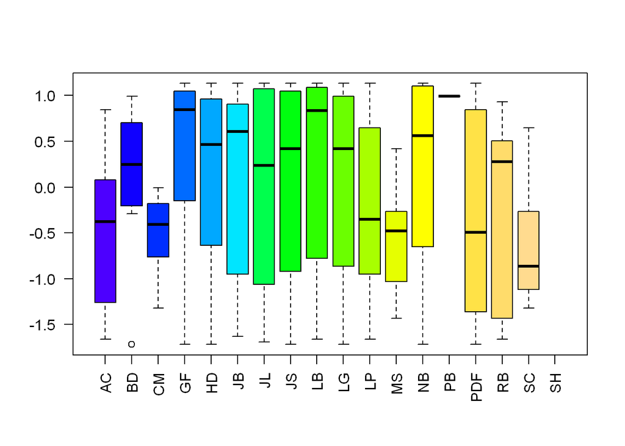

```r
plot(Goals$therapist, Goals$zgoalprogress, col = topo.colors(18), las =2)
```

“GF”, “LB”, and “PB” show significant values in the regression model, indicating that they differ somehow from the rest. Judging from the boxplot, they seem to be doing a good job: the mean goalprogress of their clients is pretty high.

The model including therapists is not really better at predicting goal progress than the goal content was: adjusted R square: 0.022.

## 2.b) Therapists and depression scores

### Influence of therapist on depression scores at the end of treatment

Of course we want to know whether some therapists are better than others in bringing patients’ depression scores down. To find this out, we run a regression with “therapist” as the predictor for “phqend”, i.e. the depression scores after the treatment.

```r
tapply(Goals$phqend, Goals$therapist, mean)
```

```
##        AC        BD        CM        GF        HD        JB        JL
##  7.500000  3.500000  6.000000  8.333333  8.375000  4.666667 10.714286
##        JS        LB        LG        LP        MS        NB        PB
##  8.222222 14.166667  8.888889 11.666667 11.666667  3.000000  0.000000
##       PDF        RB        SC        SH
##  7.000000  3.000000  7.000000  8.000000
```

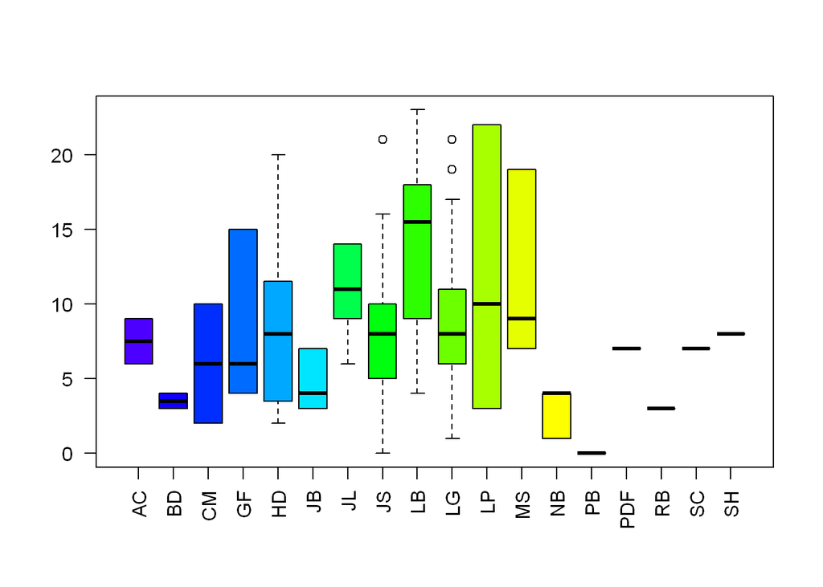

```r
boxplot(Goals$phqend ~ Goals$therapist, col = topo.colors(18), las =2)
```

```r
model_ther_depr <- lm(phqend ~ therapist, data = Goals)
summary(model_ther_depr)
```

```
##
## Call:
## lm(formula = phqend ~ therapist, data = Goals)
##
## Residuals:
##      Min       1Q   Median       3Q      Max
## -10.1667  -2.9722  -0.2222   1.7917  12.7778
##
## Coefficients:
##              Estimate Std. Error t value Pr(>|t|)
## (Intercept)    7.5000     1.1414   6.571 8.95e-11 ***
## therapistBD   -4.0000     1.6142  -2.478 0.013415 *
## therapistCM   -1.5000     1.6142  -0.929 0.353035
## therapistGF    0.8333     1.4736   0.566 0.571873
## therapistHD    0.8750     1.2106   0.723 0.470041
## therapistJB   -2.8333     1.4736  -1.923 0.054857 .
## therapistJL    3.2143     1.2942   2.484 0.013210 *
## therapistJS    0.7222     1.2032   0.600 0.548491
## therapistLB    6.6667     1.3180   5.058 5.24e-07 ***
## therapistLG    1.3889     1.2032   1.154 0.248687
## therapistLP    4.1667     1.4736   2.828 0.004805 **
## therapistMS    4.1667     1.4736   2.828 0.004805 **
## therapistNB   -4.5000     1.4736  -3.054 0.002333 **
## therapistPB   -7.5000     1.9770  -3.794 0.000159 ***
## therapistPDF  -0.5000     1.6142  -0.310 0.756830
## therapistRB   -4.5000     1.9770  -2.276 0.023094 *
## therapistSC   -0.5000     1.9770  -0.253 0.800401
## therapistSH    0.5000     1.9770   0.253 0.800401
## ---
## Signif. codes:  0 '***' 0.001 '**' 0.01 '*' 0.05 '.' 0.1 ' ' 1
##
## Residual standard error: 4.843 on 810 degrees of freedom
## Multiple R-squared:  0.2214, Adjusted R-squared:  0.2051
## F-statistic: 13.55 on 17 and 810 DF,  p-value: < 2.2e-16
```

This model seems to do a better job at predicting: adjusted R square is 0.205. This is much better than the other models we have looked at so far!

The model tells us that “BD”, “JL”, and “RB” predict PHQ scores significantly and “LB”, “LP”, “MS”, “NB”, and “PB” highly significantly.

In the boxplot we can nicely see that “BD”, “NB”, “PB”, and “RB” achieve better results: their patients have lower depression scores at the end of treatment. “LB”, “LP”, and “MS” seem to be less successful: their clients’ depression scores at the end of treatment are relatively high.

I want to validate my model. Therefore, I want to see some diagnostic plots.

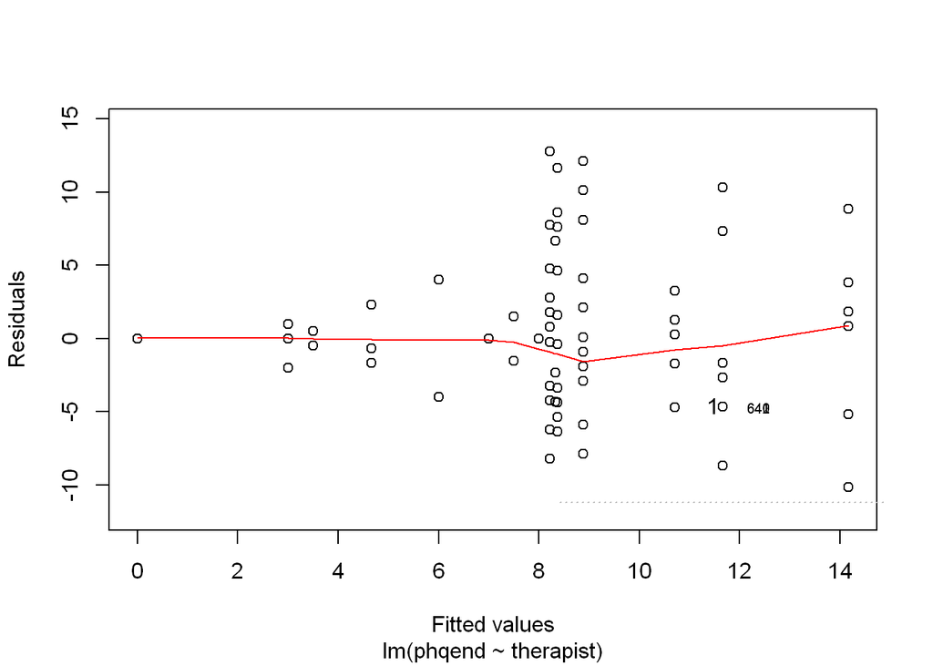

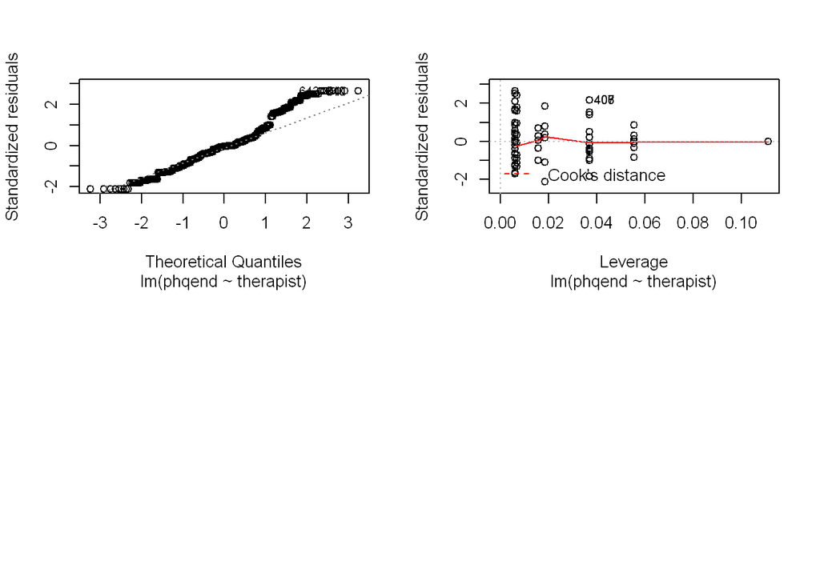

```r
plot(model_ther_depr, which = c(1, 2, 5), par(mfrow = c(2, 2)))
```

The graph that plots fitted values against residuals doesn’t look good: The variation of residuals gets larger with larger fitted values, indicating heteroscedasticity. This should be due to the different amount of goals for each therapist and therefore different variance in the respective PHQ end scores. Also the q-q-plot is questionable: in the higher quantiles, I deviates from the straight line, indicating that something is wrong with our distribution. The plot of leverage vs residuals indicates that there are not influential outliers distorting our analysis in that sense.

Let’s try and make a few predictions for imaginary new patients (“a”-“e”).

```r
new_patients <- c("a"= "MS", "b"= "LB", "c"="LP", "d" = "BD", "e" = "JL")
new_data <- data.frame(therapist =new_patients)
predict(model_ther_depr, newdata=new_data)
```

```
##        a        b        c        d        e
## 11.66667 14.16667 11.66667  3.50000 10.71429
```

In summary, the modeling suffers severely from an extremely uneven distribution of cases over the therapists.

Since I want to know about differences between therapists in regard to PHQ end scores, I will run an ANOVA with “therapist” as the independent variable.

```r
aov1 <- aov(phqend ~ therapist, data = Goals)
summary (aov1)
```

```
##              Df Sum Sq Mean Sq F value Pr(>F)
## therapist    17   5402   317.8   13.55 <2e-16 ***
## Residuals   810  18995    23.5
## ---
## Signif. codes:  0 '***' 0.001 '**' 0.01 '*' 0.05 '.' 0.1 ' ' 1
```

This indicates that there are significant differences between therapists in regard to PHQ end score.

### PHQ change instead of final PHQ scores

Not only is it important to see what the scores at the end of the treatment are but also how much they have *changed* (especially since - as we have seen earlier - entry and end scores correlate). Therefore, I run the same analysis again using change scores instead of end scores.

```r
tapply(Goals$phq_change, Goals$therapist, mean)
```

```
##        AC        BD        CM        GF        HD        JB        JL
##  6.000000  8.000000 13.000000  9.000000  9.375000 14.000000  7.571429
##        JS        LB        LG        LP        MS        NB        PB
##  8.944444  5.333333  7.777778  4.000000  3.666667 14.333333 13.000000
##       PDF        RB        SC        SH
##  8.000000  9.000000 10.000000  4.000000
```

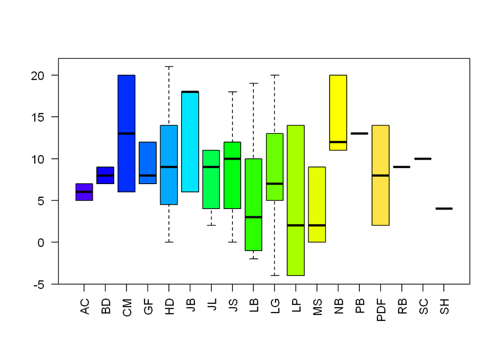

```r
boxplot(Goals$phq_change ~ Goals$therapist, col = topo.colors(18), las =2)
```

```r
model_ther_change <- lm(phq_change ~ therapist, data = Goals)
summary(model_ther_change)
```

```
##
## Call:
## lm(formula = phq_change ~ therapist, data = Goals)
##
## Residuals:
##     Min      1Q  Median      3Q     Max
## -11.778  -3.424  -0.375   4.000  13.667
##
## Coefficients:
##              Estimate Std. Error t value Pr(>|t|)
## (Intercept)    6.0000     1.2727   4.714 2.86e-06 ***
## therapistBD    2.0000     1.7999   1.111 0.266831
## therapistCM    7.0000     1.7999   3.889 0.000109 ***
## therapistGF    3.0000     1.6431   1.826 0.068246 .
## therapistHD    3.3750     1.3499   2.500 0.012612 *
## therapistJB    8.0000     1.6431   4.869 1.35e-06 ***
## therapistJL    1.5714     1.4432   1.089 0.276528
## therapistJS    2.9444     1.3416   2.195 0.028465 *
## therapistLB   -0.6667     1.4696  -0.454 0.650218
## therapistLG    1.7778     1.3416   1.325 0.185501
## therapistLP   -2.0000     1.6431  -1.217 0.223879
## therapistMS   -2.3333     1.6431  -1.420 0.155969
## therapistNB    8.3333     1.6431   5.072 4.89e-07 ***
## therapistPB    7.0000     2.2045   3.175 0.001553 **
## therapistPDF   2.0000     1.7999   1.111 0.266831
## therapistRB    3.0000     2.2045   1.361 0.173929
## therapistSC    4.0000     2.2045   1.815 0.069969 .
## therapistSH   -2.0000     2.2045  -0.907 0.364542
## ---
## Signif. codes:  0 '***' 0.001 '**' 0.01 '*' 0.05 '.' 0.1 ' ' 1
##
## Residual standard error: 5.4 on 810 degrees of freedom
## Multiple R-squared:  0.1634, Adjusted R-squared:  0.1458
## F-statistic: 9.306 on 17 and 810 DF,  p-value: < 2.2e-16
```

As for the end scores, I’m interested in differences between the therapists: ANOVA time.

```r
aov2 <- aov(phq_change ~ therapist, data = Goals)
summary (aov2)
```

```
##              Df Sum Sq Mean Sq F value Pr(>F)
## therapist    17   4613  271.35   9.306 <2e-16 ***
## Residuals   810  23618   29.16
## ---
## Signif. codes:  0 '***' 0.001 '**' 0.01 '*' 0.05 '.' 0.1 ' ' 1
```

As with the end scores, we can see that therapists do differ significantly from each other in regard to their changing PHQ scores.

## Depression yes/no as an outcome

The last thing in regard to depression scores is to see how many of certain therapists’ clients are still depressed after treatment.

```r
gmodels::CrossTable (Goals$therapist, Goals$depr)
```

```
##
##
##    Cell Contents
## |-------------------------|
## |                       N |
## | Chi-square contribution |
## |           N / Row Total |
## |           N / Col Total |
## |         N / Table Total |
## |-------------------------|
##
##
## Total Observations in Table:  828
##
##
##                 | Goals$depr
## Goals$therapist |     FALSE |      TRUE | Row Total |
## ----------------|-----------|-----------|-----------|
##              AC |        18 |         0 |        18 |
##                 |     2.612 |     5.674 |           |
##                 |     1.000 |     0.000 |     0.022 |
##                 |     0.032 |     0.000 |           |
##                 |     0.022 |     0.000 |           |
## ----------------|-----------|-----------|-----------|
##              BD |        18 |         0 |        18 |
##                 |     2.612 |     5.674 |           |
##                 |     1.000 |     0.000 |     0.022 |
##                 |     0.032 |     0.000 |           |
##                 |     0.022 |     0.000 |           |
## ----------------|-----------|-----------|-----------|
##              CM |         9 |         9 |        18 |
##                 |     0.898 |     1.950 |           |
##                 |     0.500 |     0.500 |     0.022 |
##                 |     0.016 |     0.034 |           |
##                 |     0.011 |     0.011 |           |
## ----------------|-----------|-----------|-----------|
##              GF |        18 |         9 |        27 |
##                 |     0.013 |     0.028 |           |
##                 |     0.667 |     0.333 |     0.033 |
##                 |     0.032 |     0.034 |           |
```

[output cut: 76 more lines]

```
##                 |     1.000 |     0.000 |     0.011 |
##                 |     0.016 |     0.000 |           |
##                 |     0.011 |     0.000 |           |
## ----------------|-----------|-----------|-----------|
##              SH |         9 |         0 |         9 |
##                 |     1.306 |     2.837 |           |
##                 |     1.000 |     0.000 |     0.011 |
##                 |     0.016 |     0.000 |           |
##                 |     0.011 |     0.000 |           |
## ----------------|-----------|-----------|-----------|
##    Column Total |       567 |       261 |       828 |
##                 |     0.685 |     0.315 |           |
## ----------------|-----------|-----------|-----------|
##
##
```

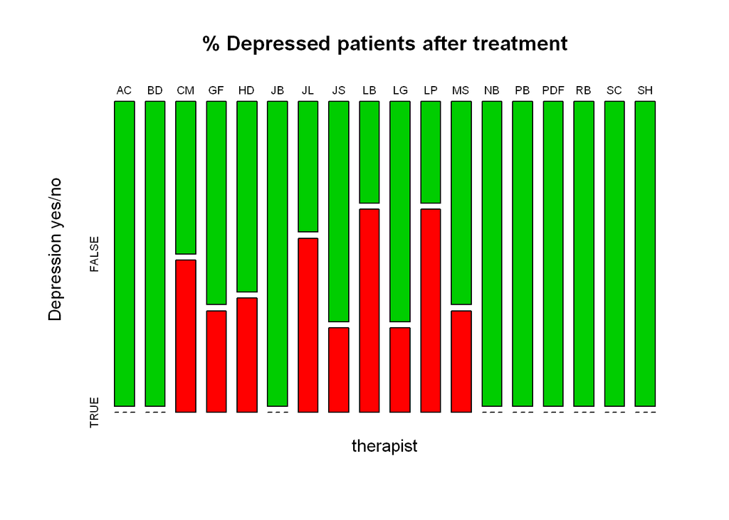

```r
ther_depr <- table(Goals$therapist, Goals$depr)
ther_depr <- prop.table(ther_depr, 1)
plot(ther_depr, type = "h", main = "% Depressed patients after treatment", xlab="therapist", ylab="Depression yes/no", col = c("35", "50"))
```

The barplot shows the percentage of depressed patients after treatment separately for each therapist, indicating that “LB”, “LP”, and “JL” leave a rather large shar of their patients with a depression at the end of treatment. The precise numbers are available from the crosstable.

## 3. Influence of therapists on goal setting

Now I want to know whether therapists differ in regard to the goals that their clients set. For this, let’s first look at some tables that show how often different therapists’ patients have certain goals. First goal category is physical activity (PA).

```r
ther_pa <- CrossTable(Goals$therapist, Goals$pagol)
```

```
##
##
##    Cell Contents
## |-------------------------|
## |                       N |
## | Chi-square contribution |
## |           N / Row Total |
## |           N / Col Total |
## |         N / Table Total |
## |-------------------------|
##
##
## Total Observations in Table:  828
##
##
##                 | Goals$pagol
## Goals$therapist |     FALSE |      TRUE | Row Total |
## ----------------|-----------|-----------|-----------|
##              AC |        17 |         1 |        18 |
##                 |     0.173 |     1.011 |           |
##                 |     0.944 |     0.056 |     0.022 |
##                 |     0.024 |     0.008 |           |
##                 |     0.021 |     0.001 |           |
## ----------------|-----------|-----------|-----------|
##              BD |        14 |         4 |        18 |
##                 |     0.122 |     0.713 |           |
##                 |     0.778 |     0.222 |     0.022 |
##                 |     0.020 |     0.033 |           |
##                 |     0.017 |     0.005 |           |
## ----------------|-----------|-----------|-----------|
##              CM |        14 |         4 |        18 |
##                 |     0.122 |     0.713 |           |
##                 |     0.778 |     0.222 |     0.022 |
##                 |     0.020 |     0.033 |           |
##                 |     0.017 |     0.005 |           |
## ----------------|-----------|-----------|-----------|
##              GF |        26 |         1 |        27 |
##                 |     0.376 |     2.199 |           |
##                 |     0.963 |     0.037 |     0.033 |
##                 |     0.037 |     0.008 |           |
```

[output cut: 76 more lines]

```
##                 |     1.000 |     0.000 |     0.011 |
##                 |     0.013 |     0.000 |           |
##                 |     0.011 |     0.000 |           |
## ----------------|-----------|-----------|-----------|
##              SH |         9 |         0 |         9 |
##                 |     0.225 |     1.315 |           |
##                 |     1.000 |     0.000 |     0.011 |
##                 |     0.013 |     0.000 |           |
##                 |     0.011 |     0.000 |           |
## ----------------|-----------|-----------|-----------|
##    Column Total |       707 |       121 |       828 |
##                 |     0.854 |     0.146 |           |
## ----------------|-----------|-----------|-----------|
##
##
```

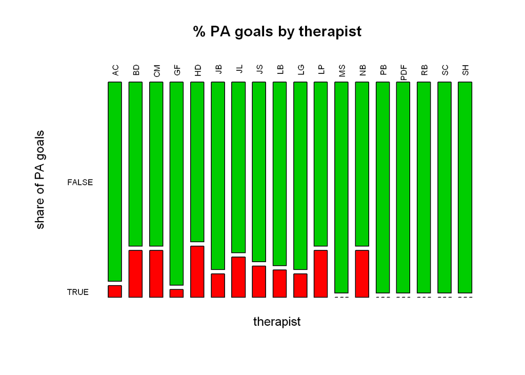

```r
library(ggplot2)
ther_pagoal <- table(Goals$therapist, Goals$pagol)
ther_pagoal <- prop.table(ther_pagoal, 1)
plot(ther_pagoal, type = "h", main = "% PA goals by therapist", xlab="therapist", ylab="share of PA goals", col = c("35", "50"), las =2)
```

This crosstable shows the total amounts of physical activity goals set by different therapists as well as their relative percentages. It’s a good overview about how much therapists differ in setting certain goals. What makes interpretation difficult is the fact that some therapists have very few goals in total. We can’t really draw inferences there. However, we can see that about 15% of all goals are PA goals. “MS”’s patients, for example, have never set a PA goal, even though there were 27 chances to do so. “HD” on the other hand seems to support PA goals: 24% of 144 goals were related to physical activity. The graph illustrates the differences in therapists setting different goals.

Next, I want to predict whether a certain goal will be chosen based on the therapist for each kind of goal independently. I do this by using a general linear model.

```r
n <- nrow(Goals)
ind <- sample(n, size=n*0.8)
train <- Goals[ind,]
test <- Goals[-ind,]

model_ther_pa <- glm(pagol ~ therapist, family = binomial(link='logit'), data = train)
summary(model_ther_pa)
```

```
##
## Call:
## glm(formula = pagol ~ therapist, family = binomial(link = "logit"),
##     data = train)
##
## Deviance Residuals:
##      Min        1Q    Median        3Q       Max
## -0.79806  -0.66805  -0.53839  -0.00013   2.50419
##
## Coefficients:
##               Estimate Std. Error z value Pr(>|z|)
## (Intercept)    -2.7081     1.0328  -2.622  0.00874 **
## therapistBD     1.5294     1.1805   1.296  0.19513
## therapistCM     1.4088     1.2210   1.154  0.24860
## therapistGF    -0.3830     1.4533  -0.264  0.79214
## therapistHD     1.7272     1.0548   1.638  0.10151
## therapistJB     0.8622     1.2053   0.715  0.47437
## therapistJL     1.3924     1.0872   1.281  0.20029
## therapistJS     0.8499     1.0652   0.798  0.42494
## therapistLB     0.9734     1.1237   0.866  0.38634
## therapistLG     0.7802     1.0669   0.731  0.46463
## therapistLP     1.3218     1.1475   1.152  0.24936
## therapistMS   -15.8580  1360.0646  -0.012  0.99070
## therapistNB     1.3730     1.1486   1.195  0.23193
## therapistPB   -15.8580  2174.2131  -0.007  0.99418
## therapistPDF  -15.8580  1743.2488  -0.009  0.99274
## therapistRB   -15.8580  2465.3259  -0.006  0.99487
## therapistSC   -15.8580  2306.1012  -0.007  0.99451
## therapistSH   -15.8580  2662.8563  -0.006  0.99525
## ---
## Signif. codes:  0 '***' 0.001 '**' 0.01 '*' 0.05 '.' 0.1 ' ' 1
##
## (Dispersion parameter for binomial family taken to be 1)
##
##     Null deviance: 568.95  on 661  degrees of freedom
## Residual deviance: 527.92  on 644  degrees of freedom
## AIC: 563.92
##
## Number of Fisher Scoring iterations: 17
```

```r
coef(model_ther_pa)
```

```
##  (Intercept)  therapistBD  therapistCM  therapistGF  therapistHD
##   -2.7080502    1.5293952    1.4087672   -0.3829923    1.7272209
##  therapistJB  therapistJL  therapistJS  therapistLB  therapistLG
##    0.8622235    1.3923734    0.8499157    0.9734491    0.7801586
##  therapistLP  therapistMS  therapistNB  therapistPB therapistPDF
##    1.3217558  -15.8580183    1.3730491  -15.8580183  -15.8580183
##  therapistRB  therapistSC  therapistSH
##  -15.8580183  -15.8580183  -15.8580183
```

This indicates that we can’t determine whether a PA goal is set when knowing the therapist. None of the therapist factor levels reaches significance.

I’m not including crosstabs for the other goals types as well. As it would be quite a lot to go through, I will not analyze those here.

# Conclusion